# MITxweek-7

Raka

11/9/2020

## Task 1: Election Forecasting Revisited

n this homework problem, we’ll revisit our logistic regression model from Unit 3, and learn how to plot the output on a map of the United States. Unlike what we did in the Crime lecture, this time we’ll be plotting predictions rather than data!

First, load the ggplot2, maps, and ggmap packages using the library function. All three packages should be installed on your computer from lecture, but if not, you may need to install them too using the install.packages function.

Then, load the US map and save it to the variable statesMap, like we did during the Crime lecture:

statesMap = map_data(“state”)

The maps package contains other built-in maps, including a US county map, a world map, and maps for France and Italy.

```r
library(ggplot2)
library(maps)
library(ggmap)
```

If you look at the structure of the statesMap data frame using the str function, you should see that there are 6 variables. One of the variables, group, defines the different shapes or polygons on the map. Sometimes a state may have multiple groups, for example, if it includes islands. How many different groups are there?

```r
statesMap <- map_data("state")
str(statesMap)
```

```
## 'data.frame':    15537 obs. of  6 variables:
##  $ long     : num  -87.5 -87.5 -87.5 -87.5 -87.6 ...
##  $ lat      : num  30.4 30.4 30.4 30.3 30.3 ...
##  $ group    : num  1 1 1 1 1 1 1 1 1 1 ...
##  $ order    : int  1 2 3 4 5 6 7 8 9 10 ...
##  $ region   : chr  "alabama" "alabama" "alabama" "alabama" ...
##  $ subregion: chr  NA NA NA NA ...
```

```r
table(statesMap$group)
```

```
##
##    1    2    3    4    5    6    7    8    9   10   11   12   13   14   15   16
##  202  149  312  516   79   91   94   10  872  381  233  329  257  256  113  397
##   17   18   19   20   21   22   23   24   25   26   27   28   29   30   31   32
##  650  399  566   36  220   30  460  370  373  382  315  238  208   70  125  205
##   33   34   35   36   37   38   39   40   41   42   43   44   45   46   47   48
##   78   16  290   21  168   37  733   12  105  238  284  236  172   66  304  166
##   49   50   51   52   53   54   55   56   57   58   59   60   61   62   63
##  289 1088   59  129   96   15  623   17   17   19   44  448  373  388   68
```

# Maps of the US

You can draw a map of the United States by typing the following in your R console:

ggplot(statesMap, aes(x = long, y = lat, group = group)) + geom_polygon(fill = “white”, color = “black”)

We specified two colors in geom_polygon – fill and color. Which one defined the color of the outline of the states?

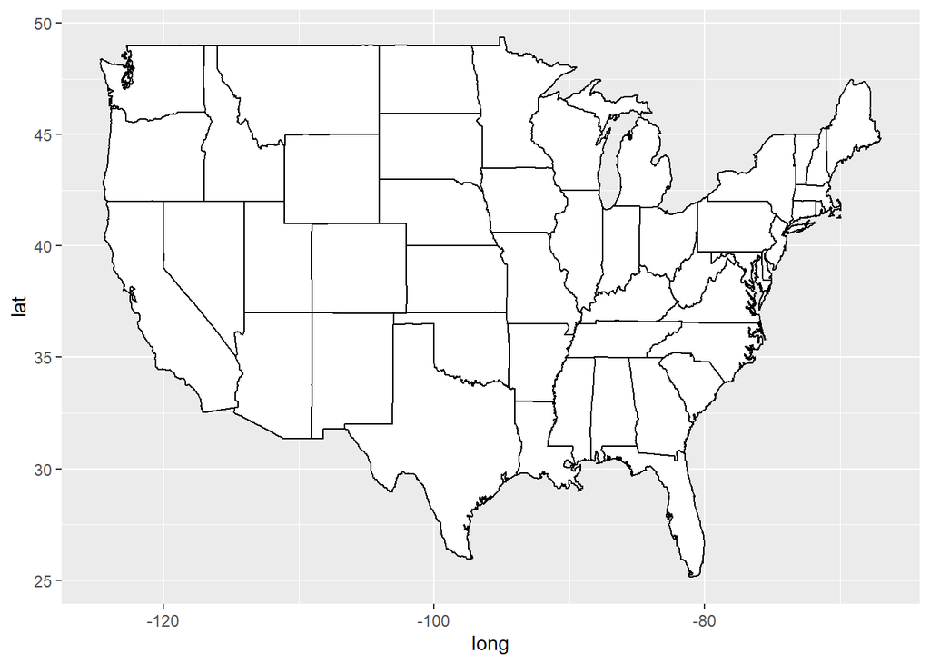

```r
ggplot(statesMap, aes(x = long, y = lat, group = group)) + geom_polygon(fill = "white", color = "black")
```

# Coloring the states by Predictions

Load the data using the read.csv function, and call it “polling”. Then split the data using the subset function into a training set called “Train” that has observations from 2004 and 2008, and a testing set called “Test” that has observations from 2012.

Then, create a logistic regression model and make predictions on the test set using the following commands:

mod2 = glm(Republican~SurveyUSA+DiffCount, data=Train, family=“binomial”)

TestPrediction = predict(mod2, newdata=Test, type=“response”)

TestPrediction gives the predicted probabilities for each state, but let’s also create a vector of Republican/Democrat predictions by using the following command:

TestPredictionBinary = as.numeric(TestPrediction > 0.5)

Now, put the predictions and state labels in a data.frame so that we can use ggplot:

predictionDataFrame = data.frame(TestPrediction, TestPredictionBinary, Test$State)

To make sure everything went smoothly, answer the following questions.

For how many states is our binary prediction 1 (for 2012), corresponding to Republican?

```r
polling <- read.csv("PollingImputed.csv")

Train <- subset(polling, Year <= 2008)
Test <- subset(polling, Year > 2008)

mod2 <- glm(Republican~SurveyUSA+DiffCount, data=Train, family="binomial")
TestPrediction <-  predict(mod2, newdata=Test, type="response")

TestPredictionBinary <- as.numeric(TestPrediction > 0.5)

table(TestPredictionBinary)
```

```
## TestPredictionBinary
##  0  1
## 23 22
```

```r
mean(TestPrediction)
```

```
## [1] 0.4852626
```

# Coloring the states

Now, we need to merge “predictionDataFrame” with the map data “statesMap”, like we did in lecture. Before doing so, we need to convert the Test.State variable to lowercase, so that it matches the region variable in statesMap. Do this by typing the following in your R console:

predictionDataFrame$region = tolower(predictionDataFrame$Test.State)

Now, merge the two data frames using the following command:

predictionMap = merge(statesMap, predictionDataFrame, by = “region”)

Lastly, we need to make sure the observations are in order so that the map is drawn properly, by typing the following:

predictionMap = predictionMap[order(predictionMap$order),]

How many observations are there in predictionMap?

```r
predictionDataFrame <- Test
predictionDataFrame$region <- tolower(predictionDataFrame$State)
predictionDataFrame$Predicted <- TestPredictionBinary

predictionDataFrame$Predicted_Val <- TestPrediction

View(predictionDataFrame)

# Merging the data
predictionMap <- merge(statesMap, predictionDataFrame, by = "region")

#make sure everything's in order
predictionMap <- predictionMap[order(predictionMap$order),]
```

# Coloring the staets by predictions

Now we are ready to color the US map with our predictions! You can color the states according to our binary predictions by typing the following in your R console:

ggplot(predictionMap, aes(x = long, y = lat, group = group, fill = TestPredictionBinary)) + geom_polygon(color = “black”)

The states appear light blue and dark blue in this map. Which color represents a Republican prediction?

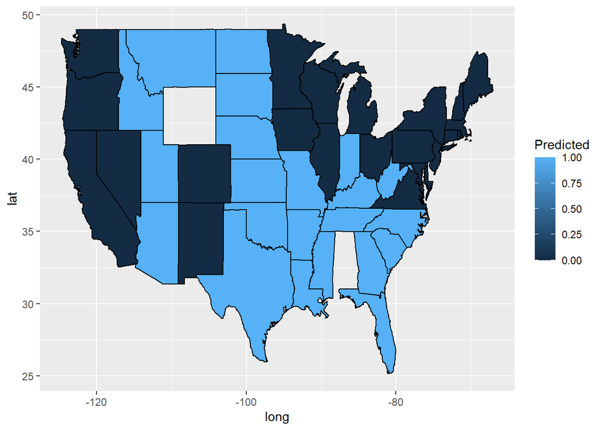

```r
ggplot(predictionMap, aes(x = long, y = lat, group = group, fill = Predicted)) + geom_polygon(color = "black")
```

# Coloring the outcomes: discrete numbers

We see that the legend displays a blue gradient for outcomes between 0 and 1. However, when plotting the binary predictions there are only two possible outcomes: 0 or 1. Let’s replot the map with discrete outcomes. We can also change the color scheme to blue and red, to match the blue color associated with the Democratic Party in the US and the red color associated with the Republican Party in the US. This can be done with the following command:

ggplot(predictionMap, aes(x = long, y = lat, group = group, fill = TestPredictionBinary))+ geom_polygon(color = “black”) + scale_fill_gradient(low = “blue”, high = “red”, guide = “legend”, breaks= c(0,1), labels = c(“Democrat”, “Republican”), name = “Prediction 2012”)

Alternatively, we could plot the probabilities instead of the binary predictions. Change the plot command above to instead color the states by the variable TestPrediction. You should see a gradient of colors ranging from red to blue. Do the colors of the states in the map for TestPrediction look different from the colors of the states in the map with TestPredictionBinary? Why or why not?

NOTE: If you have a hard time seeing the red/blue gradient, feel free to change the color scheme, by changing the arguments low = “blue” and high = “red” to colors of your choice (to see all of the color options in R, type colors() in your R console). You can even change it to a gray scale, by changing the low and high colors to “gray” and “black”.

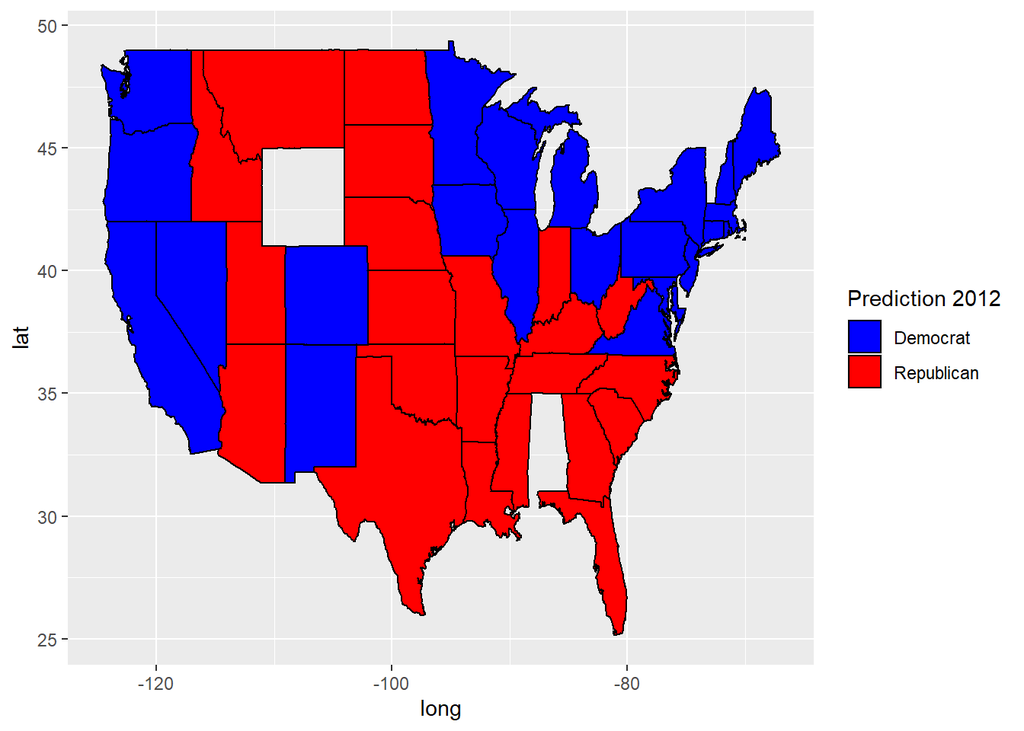

```r
ggplot(predictionMap, aes(x = long, y = lat, group = group, fill = Predicted))+
  geom_polygon(color = "black") +
  scale_fill_gradient(low = "blue", high = "red", guide = "legend", breaks= c(0,1), labels = c("Democrat", "Republican"), name = "Prediction 2012")
```

Or…

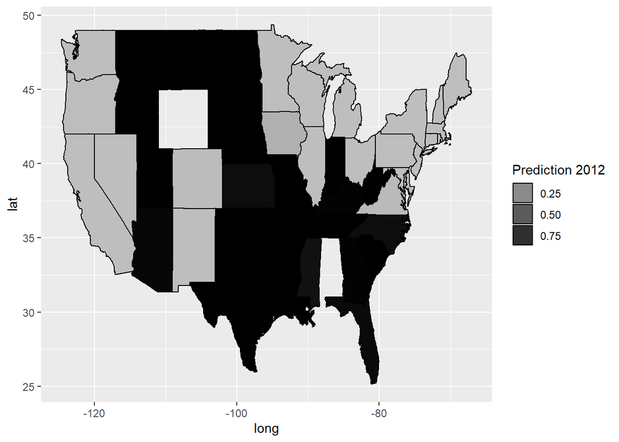

```r
ggplot(predictionMap, aes(x = long, y = lat, group = group, fill = Predicted_Val))+
  geom_polygon(color = "black") +
  scale_fill_gradient(low = "gray", high = "black", guide = "legend", name = "Prediction 2012")
```

# Parameter settings

In this part, we’ll explore what the different parameter settings of geom_polygon do. Throughout the problem, use the help page for geom_polygon, which can be accessed by ?geom_polygon. To see more information about a certain parameter, just type a question mark and then the parameter name to get the help page for that parameter. Experiment with different parameter settings to try and replicate the plots!

We’ll be asking questions about the following three plots:

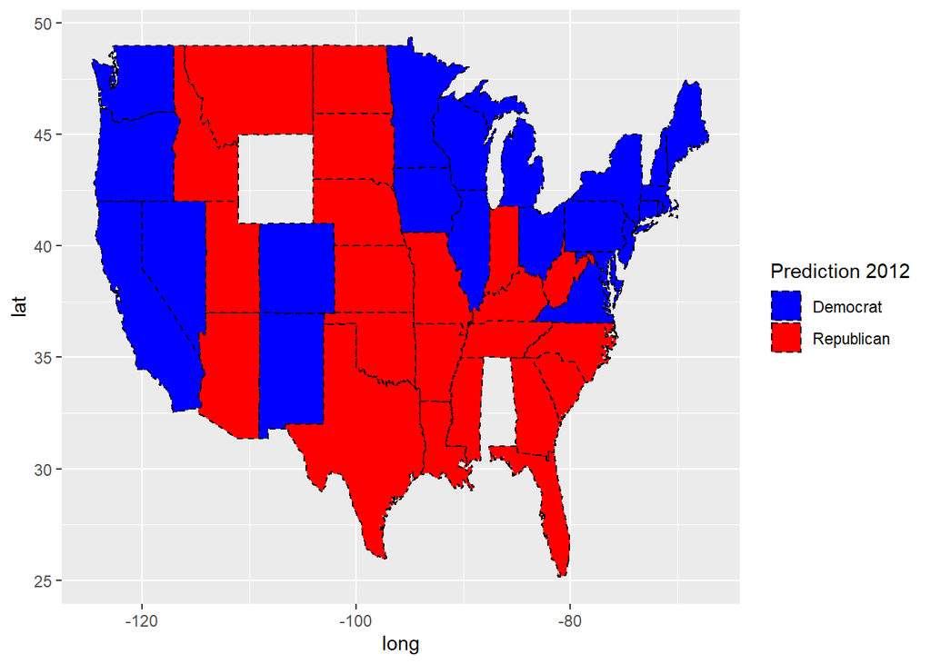

```r
#Plot 1 -- dashed
ggplot(predictionMap, aes(x = long, y = lat, group = group, fill = Predicted))+
  geom_polygon(color = "black", linetype = 2) +
  scale_fill_gradient(low = "blue", high = "red", guide = "legend", breaks= c(0,1), labels = c("Democrat", "Republican"), name = "Prediction 2012")
```

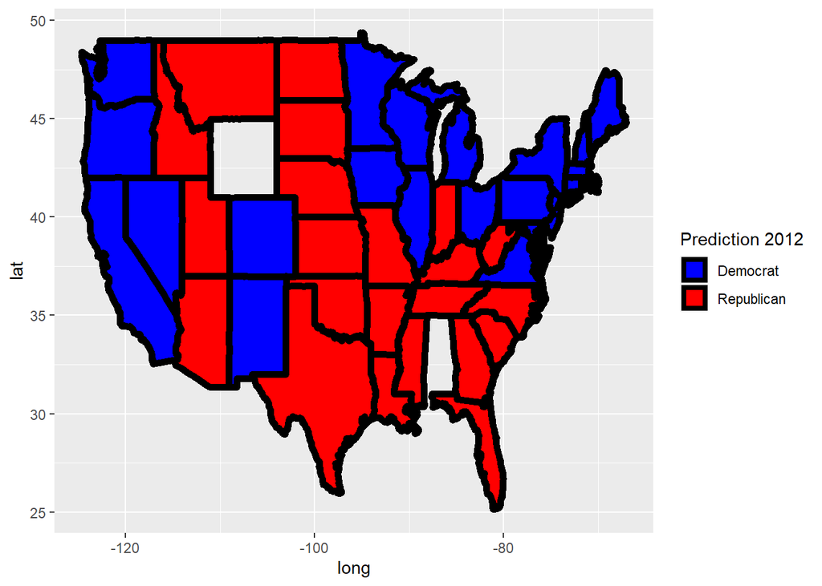

```r
#Plot 2-- bold lines
ggplot(predictionMap, aes(x = long, y = lat, group = group, fill = Predicted))+
  geom_polygon(color = "black", size = 2) +
  scale_fill_gradient(low = "blue", high = "red", guide = "legend", breaks= c(0,1), labels = c("Democrat", "Republican"), name = "Prediction 2012")
```

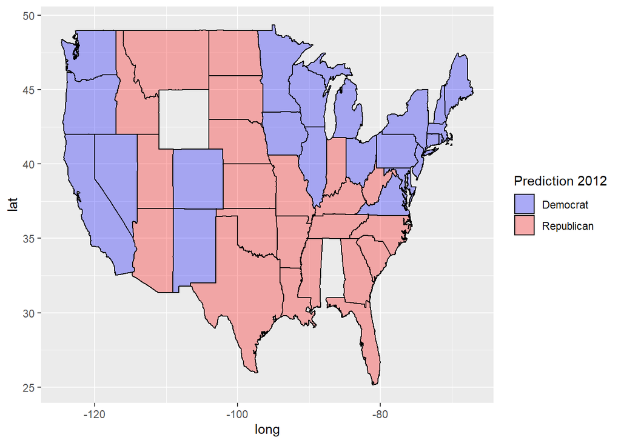

```r
#Plot3-- opacity
ggplot(predictionMap, aes(x = long, y = lat, group = group, fill = Predicted))+
  geom_polygon(color = "black", alpha = 0.3) +
  scale_fill_gradient(low = "blue", high = "red", guide = "legend", breaks= c(0,1), labels = c("Democrat", "Republican"), name = "Prediction 2012")
```

## Task 2: Visualizing Network Data

The cliche goes that the world is an increasingly interconnected place, and the connections between different entities are often best represented with a graph. Graphs are comprised of vertices (also often called “nodes”) and edges connecting those nodes. In this assignment, we will learn how to visualize networks using the igraph package in R.

For this assignment, we will visualize social networking data using anonymized data from Facebook; this data was originally curated in a recent paper about computing social circles in social networks. In our visualizations, the vertices in our network will represent Facebook users and the edges will represent these users being Facebook friends with each other.

The first file we will use, edges.csv, contains variables V1 and V2, which label the endpoints of edges in our network. Each row represents a pair of users in our graph who are Facebook friends. For a pair of friends A and B, edges.csv will only contain a single row – the smaller identifier will be listed first in this row. From this row, we will know that A is friends with B and B is friends with A.

```r
edges <- read.csv("edges.csv")
users <- read.csv("users.csv")

nrow(edges)*2/nrow(users)
```

```
## [1] 4.949153
```

```r
table(users$locale)
```

```
##
##     A  B
##  3  6 50
```

```r
table(users$gender, users$school)
```

```
##
##         A AB
##      1  1  0
##   A 11  3  1
##   B 28 13  1
```

# Creating a network

We will be using the igraph package to visualize networks; install and load this package using the install.packages and library commands.

We can create a new graph object using the graph.data.frame() function. Based on ?graph.data.frame, which of the following commands will create a graph g describing our social network, with the attributes of each user correctly loaded?

Note: A directed graph is one where the edges only go one way – they point from one vertex to another. The other option is an undirected graph, which means that the relations between the vertices are symmetric.

```r
library(igraph)
g <- graph.data.frame(edges, FALSE, users)
```

# Creating networks

Use the correct command from Problem 2.1 to load the graph g.

Now, we want to plot our graph. By default, the vertices are large and have text labels of a user’s identifier. Because this would clutter the output, we will plot with no text labels and smaller vertices:

plot(g, vertex.size=5, vertex.label=NA)

In this graph, there are a number of groups of nodes where all the nodes in each group are connected but the groups are disjoint from one another, forming “islands” in the graph. Such groups are called “connected components,” or “components” for short. How many connected components with at least 2 nodes are there in the graph?

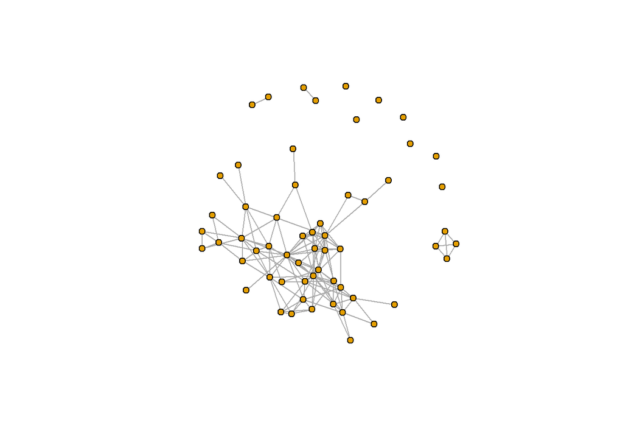

```r
plot(g, vertex.size = 5, vertex.label = NA)
```

In our graph, the “degree” of a node is its number of friends. We have already seen that some nodes in our graph have degree 0 (these are the nodes with no friends), while others have much higher degree. We can use degree(g) to compute the degree of all the nodes in our graph g.

How many users are friends with 10 or more other Facebook users in this network?

```r
degree(g)
```

```
## 3981 3982 3983 3984 3985 3986 3987 3988 3989 3990 3991 3992 3993 3994 3995  594
##    7   13    1    0    5    8    1    6    5    3    2    2    5   10    8    3
## 3996 3997 3998 3999 4000 4001 4002 4003 4004 4005 4006 4007 4008 4009 4010 4011
##    3   10   13    3    8    1    6    4    9    2    1    3    0    9    0    3
## 4012 4013 4014 4015 4016 4017 4018 4019 4020 4021 4022 4023 4024 4025 4026 4027
##    1    5   11    0    3    8    6    7    7   10    0   17    0    3    8    6
## 4028 4029 4030 4031 4032 4033 4034 4035 4036 4037 4038
##    1    1   18   10    1    2    1    0    1    3    8
```

```r
class(degree(g))
```

```
## [1] "numeric"
```

```r
table(degree(g))
```

```
##
##  0  1  2  3  4  5  6  7  8  9 10 11 13 17 18
##  7 10  4  9  1  4  4  3  6  2  4  1  2  1  1
```

# modifying network elements

In a network, it’s often visually useful to draw attention to “important” nodes in the network. While this might mean different things in different contexts, in a social network we might consider a user with a large number of friends to be an important user. From the previous problem, we know this is the same as saying that nodes with a high degree are important users.

To visually draw attention to these nodes, we will change the size of the vertices so the vertices with high degrees are larger. To do this, we will change the “size” attribute of the vertices of our graph to be an increasing function of their degrees:

V(g)$size = degree(g)/2+2

Now that we have specified the vertex size of each vertex, we will no longer use the vertex.size parameter when we plot our graph:

plot(g, vertex.label=NA)

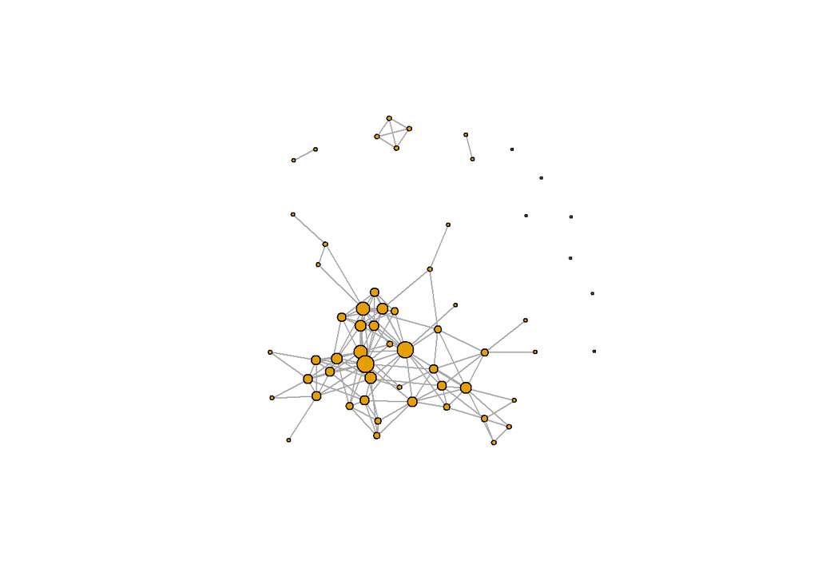

```r
V(g)$size = degree(g)/2+2
plot(g, vertex.label=NA)
```

```r
V(g)
```

```
## + 59/59 vertices, named, from fb6fca1:
##  [1] 3981 3982 3983 3984 3985 3986 3987 3988 3989 3990 3991 3992 3993 3994 3995
## [16] 594  3996 3997 3998 3999 4000 4001 4002 4003 4004 4005 4006 4007 4008 4009
## [31] 4010 4011 4012 4013 4014 4015 4016 4017 4018 4019 4020 4021 4022 4023 4024
## [46] 4025 4026 4027 4028 4029 4030 4031 4032 4033 4034 4035 4036 4037 4038
```

```r
max(V(g)$size)
```

```
## [1] 11
```

```r
min(V(g)$size)
```

```
## [1] 2
```

# Coloring vertices

Thus far, we have changed the “size” attributes of our vertices. However, we can also change the colors of vertices to capture additional information about the Facebook users we are depicting.

When changing the size of nodes, we first obtained the vertices of our graph with V(g) and then accessed the the size attribute with V(g)$size. To change the color, we will update the attribute V(g)$color.

To color the vertices based on the gender of the user, we will need access to that variable. When we created our graph g, we provided it with the data frame users, which had variables gender, school, and locale. These are now stored as attributes V(g)$gender, V(g)$school, and V(g)$locale.

We can update the colors by setting the color to black for all vertices, than setting it to red for the vertices with gender A and setting it to gray for the vertices with gender B:

V(g)$color = “black”

V(g)$color[V(g)$gender == “A”] = “red”

V(g)$color[V(g)$gender == “B”] = “gray”

Plot the resulting graph. What is the gender of the users with the highest degree in the graph?

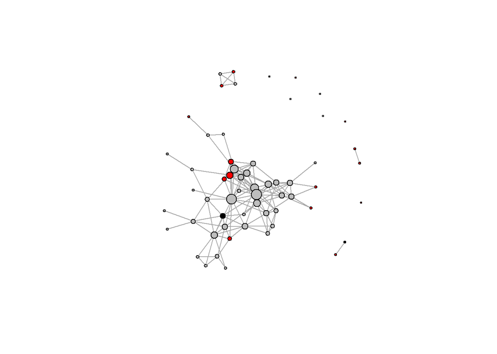

```r
V(g)$color <-  "black"

V(g)$color[V(g)$gender == "A"] <-  "red"

V(g)$color[V(g)$gender == "B"] <-  "gray"

plot(g, vertex.label=NA)
```

Now, color the vertices based on the school that each user in our network attended.

Are the two users who attended both schools A and B Facebook friends with each other?

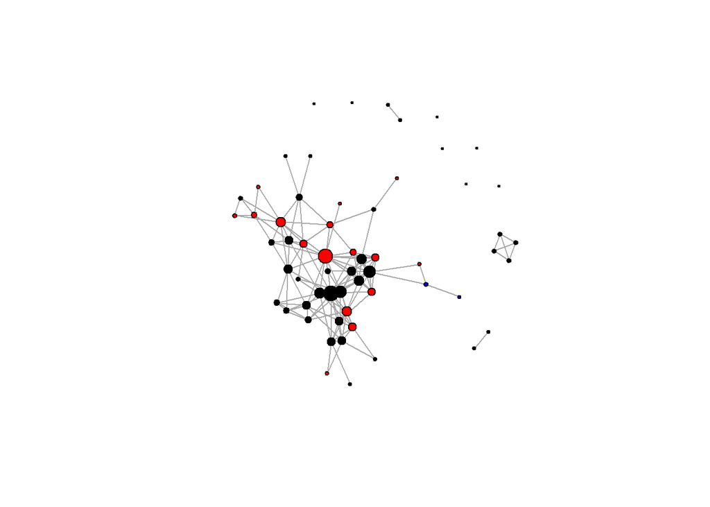

```r
V(g)$color <-  "black"

V(g)$color[V(g)$school == "A"] <-  "red"

V(g)$color[V(g)$school == "AB"] <-  "blue"

plot(g, vertex.label=NA)
```

Now, color the vertices based on the locale of the user.

The large connected component is most associated with which locale?

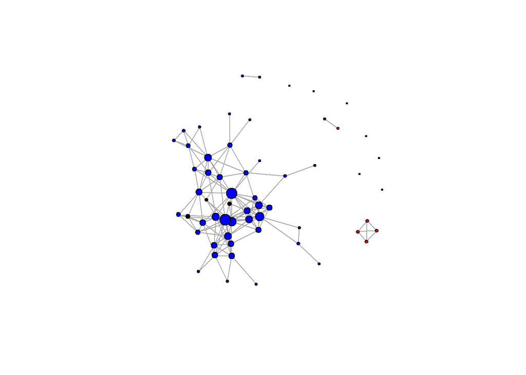

```r
V(g)$color <-  "black"

V(g)$color[V(g)$locale == "A"] <-  "red"

V(g)$color[V(g)$locale == "B"] <-  "blue"

plot(g, vertex.label=NA)
```

## Task 3: Word CLOUDS :))

Earlier in the course, we used text analytics as a predictive tool, using word frequencies as independent variables in our models. However, sometimes our goal is to understand commonly occurring topics in text data instead of to predict the value of some dependent variable. In such cases, word clouds can be a visually appealing way to display the most frequent words in a body of text.

```r
library(tm)
tweets <- read.csv("tweets.csv", stringsAsFactors = FALSE)
corpus <- Corpus(VectorSource(tweets$Tweet))

corpus <- tm_map(corpus, content_transformer(tolower))
corpus <- tm_map(corpus, removePunctuation)
corpus <- tm_map(corpus, removeWords, stopwords("english"))
dtm <- DocumentTermMatrix(corpus)

allTweets <- as.data.frame(as.matrix(dtm))
dtm
```

```
## <<DocumentTermMatrix (documents: 1181, terms: 3780)>>
## Non-/sparse entries: 10273/4453907
## Sparsity           : 100%
## Maximal term length: 115
## Weighting          : term frequency (tf)
```

# Building Word Clouds

Install and load the “wordcloud” package, which is needed to build word clouds.

As we can read from ?wordcloud, we will need to provide the function with a vector of words and a vector of word frequencies. Which function can we apply to allTweets to get a vector of the words in our dataset, which we’ll pass as the first argument to wordcloud()?

```r
library(wordcloud)
colSums(allTweets)
```

[output not shown]

[output cut: 7505 more lines]

[output not shown]

# Building a word cloud

Use allTweets to build a word cloud. Make sure to check out the help page for wordcloud if you are not sure how to do this.

Because we are plotting a large number of words, you might get warnings that some of the words could not be fit on the page and were therefore not plotted – this is especially likely if you are using a smaller screen. You can address these warnings by plotting the words smaller. From ?wordcloud, we can see that the “scale” parameter controls the sizes of the plotted words. By default, the sizes range from 4 for the most frequent words to 0.5 for the least frequent, as denoted by the parameter “scale=c(4, 0.5)”. We could obtain a much smaller plot with, for instance, parameter “scale=c(2, 0.25)”.

What is the most common word across all the tweets (it will be the largest in the outputted word cloud)? Please type the word exactly how you see it in the word cloud. The most frequent word might not be printed if you got a warning about words being cut off – if this happened, be sure to follow the instructions in the paragraph above.

```
## Warning in wordcloud(words = colnames(allTweets), freq = colSums(allTweets)):
## apple could not be fit on page. It will not be plotted.
```

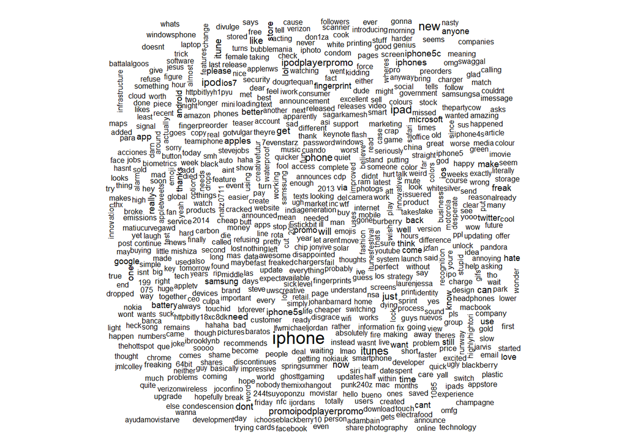

```r
wordcloud(words = colnames(allTweets), freq = colSums(allTweets))
```

# with new corpus #2

In the previous subproblem, we noted that there is one word with a much higher frequency than the other words. Repeat the steps to load and pre-process the corpus, this time removing the most frequent word in addition to all elements of stopwords(“english”) in the call to tm_map with removeWords. For a refresher on how to remove this additional word, see the Twitter text analytics lecture.

Replace allTweets with the document-term matrix of this new corpus – we will use this updated corpus for the remainder of the assignment.

Create a word cloud with the updated corpus. What is the most common word in this new corpus (the largest word in the outputted word cloud)? The most frequent word might not be printed if you got a warning about words being cut off – if this happened, be sure to follow the instructions in the previous problem.

```r
corpus2 <- Corpus(VectorSource(tweets$Tweet))

corpus2 <- tm_map(corpus2, content_transformer(tolower))
```

```
## Warning in tm_map.SimpleCorpus(corpus2, content_transformer(tolower)):
## transformation drops documents
```

```r
corpus2 <- tm_map(corpus2, removePunctuation)
```

```
## Warning in tm_map.SimpleCorpus(corpus2, removePunctuation): transformation drops
## documents
```

```r
corpus2 <- tm_map(corpus2, removeWords, c("apple",stopwords("english")))
```

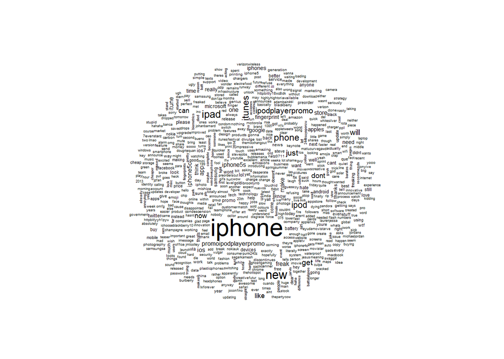

```r
dtm2 <- DocumentTermMatrix(corpus2)

allTweets2 <- as.data.frame(as.matrix(dtm2))

wordcloud(words = colnames(allTweets2), freq = colSums(allTweets2), scale = c(2,0.25))
```